# Problem Set 4 Coding Solutions

STAT 436, Spring 2025

# Geospatial Datasets

For each of the datasets below, specify whether it is in a vector or raster data format. If it is in a vector data format, explain which types of geometries it contains (e.g., a point or linestring). Explain your reasoning.

1. [NYC Building Footprints](https://uwmadison.box.com/shared/static/qfmrp9srsoq0a7oj0e7xmgu5spojr33e.geojson)

Note: We have included visualizations, but these were not required for credit.

Vector. Each building is a multipolygon geometry, see the `Geometry type` field. Each row gives the coordinates of the boundaries of the building.

```r
buildings <- read_sf("https://uwmadison.box.com/shared/static/qfmrp9srsoq0a7oj0e7xmgu5spojr33e.geojson")
buildings
```

```
## Simple feature collection with 2726 features and 0 fields
## Geometry type: MULTIPOLYGON
## Dimension:     XY
## Bounding box:  xmin: -74.0048 ymin: 40.7032 xmax: -73.9648 ymax: 40.7432
## Geodetic CRS:  WGS 84
## # A tibble: 2,726 × 1
##                                                                         geometry
##                                                               <MULTIPOLYGON [°]>
##  1 (((-73.99587 40.7432, -73.99348 40.74228, -73.99381 40.74179, -73.99639 40.7…
##  2 (((-74.00315 40.73253, -74.00318 40.73254, -74.00319 40.73255, -74.0031 40.7…
##  3 (((-74.00129 40.72418, -74.00212 40.72305, -74.00277 40.72332, -74.00209 40.…
##  4 (((-73.99679 40.7239, -73.99631 40.7246, -73.99603 40.72449, -73.99652 40.72…
##  5 (((-73.99473 40.72505, -73.99445 40.72575, -73.99433 40.72573, -73.99437 40.…
##  6 (((-73.99951 40.73009, -74.00019 40.72914, -74.00052 40.72927, -74.00047 40.…
##  7 (((-73.992 40.7274, -73.99214 40.72745, -73.99202 40.72761, -73.99192 40.727…
##  8 (((-73.98689 40.714, -73.98707 40.71399, -73.98709 40.71422, -73.98691 40.71…
##  9 (((-73.99174 40.71495, -73.9913 40.71594, -73.99069 40.71578, -73.99113 40.7…
## 10 (((-73.99187 40.71858, -73.99223 40.71778, -73.99293 40.71796, -73.99257 40.…
## # ℹ 2,716 more rows
```

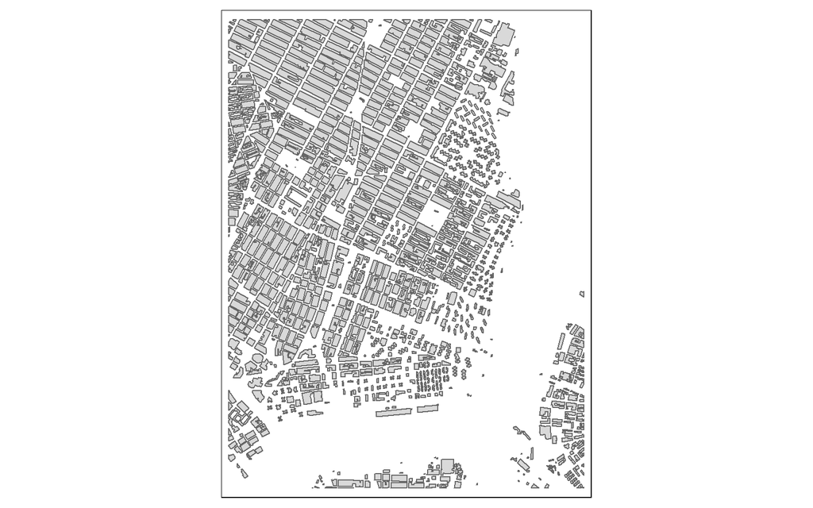

```r
library(tmap)
tm_shape(buildings) +
    tm_polygons()
```

2. [Africa Population 2020](https://github.com/krisrs1128/stat436_s24/raw/main/data/afripop2020.tif)

Raster. This is shown in the `RasterBrick` data class below. Population is given for each 0.1666 degrees of the longitude/latitude on the continent.

```r
library(raster)
afripop <- brick("https://github.com/krisrs1128/stat436_f24/raw/refs/heads/main/data/afripop2020.tif")
afripop
```

```
## class      : RasterBrick
## dimensions : 434, 413, 179242, 1  (nrow, ncol, ncell, nlayers)
## resolution : 0.1666667, 0.1666667  (x, y)
## extent     : -17.62625, 51.20708, -34.97542, 37.35792  (xmin, xmax, ymin, ymax)
## crs        : +proj=longlat +datum=WGS84 +no_defs
## source     : afripop2020.tif
## names      : afripop2020
## min values :           0
## max values :    21181.16
```

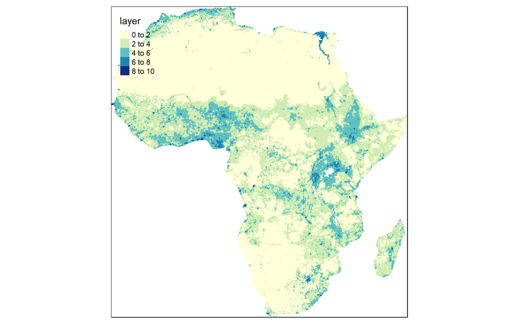

```r
tm_shape(log(1 + afripop)) +
    tm_raster(palette = c('#ffffd9','#edf8b1','#c7e9b4','#7fcdbb','#41b6c4','#1d91c0','#225ea8','#0c2c84'))
```

3. [Himalayan Glacial Lakes](https://raw.githubusercontent.com/krisrs1128/stat436_s23/main/data/GL_3basins_2015.topojson)

Vector. Each lake is a polygon.

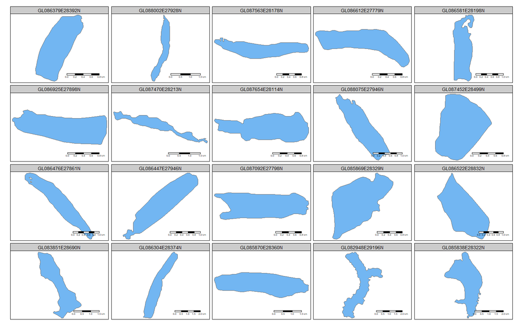

```r
read_sf("https://raw.githubusercontent.com/krisrs1128/stat436_s23/main/data/GL_3basins_2015.topojson") |>
    mutate(GL_ID = fct_reorder(GL_ID, Area)) |>
    slice_max(Area, n = 20) |>
    tm_shape() +
    tm_polygons(col = "#72B6F2") +
    tm_facets("GL_ID", ncol = 5) +
    tm_scale_bar()
```

4. [Wisconsin EV Charging](https://github.com/krisrs1128/stat436_s24/raw/main/data/ev.geojson)

Vector. Each station is a point geometry, and the rows give their latitude and longitude coordinates. Can you recognize the outlines of Wisconsin from this? Which regions have the most stations?.

```r
ev <- read_sf("https://github.com/krisrs1128/stat436_s24/raw/main/data/ev.geojson")
ev
```

```
## Simple feature collection with 846 features and 68 fields
## Geometry type: POINT
## Dimension:     XY
## Bounding box:  xmin: -92.75408 ymin: 42.51329 xmax: -87.02122 ymax: 46.94643
## Geodetic CRS:  WGS 84
## # A tibble: 846 × 69
##    OBJECTID FUEL_TYPE_ STATION_NA  STREET_ADD INTERSECTI CITY  STATE ZIP   PLUS4
##       <int> <chr>      <chr>       <chr>      <chr>      <chr> <chr> <chr> <chr>
##  1      235 LPG        AmeriGas    700 Count… Route 12 … Elkh… WI    53121 <NA>
##  2      287 LPG        AmeriGas    4117 Term… Near High… McFa… WI    53558 <NA>
##  3      288 LPG        Ferrellgas  1301 S St… <NA>       Madi… WI    53716 <NA>
##  4      289 LPG        Roche-A-Cr… 503 S Mai… Highway 1… Adams WI    53910 <NA>
##  5      290 LPG        United Co-… 7160 N Ra… 0.5 mile … Beav… WI    53916 <NA>
##  6      291 LPG        Lakes Gas … 50 Packer… Off Highw… Robe… WI    54023 <NA>
##  7      292 LPG        Ferrellgas  801 Prosp… East on C… Osce… WI    54020 <NA>
##  8      293 LPG        Superior G… 212 W 14t… 1.5 block… Mars… WI    54449 <NA>
##  9      294 LPG        AmeriGas    112 S Par… Near High… Rhin… WI    54501 <NA>
## 10      295 LPG        Midland Se… 411 Sanbo… From the … Ashl… WI    54806 <NA>
## # ℹ 836 more rows
## # ℹ 60 more variables: STATION_PH <chr>, STATUS_COD <chr>, EXPECTED_D <date>,
## #   GROUPS_WIT <chr>, ACCESS_DAY <chr>, CARDS_ACCE <chr>, BD_BLENDS <chr>,
## #   NG_FILL_TY <chr>, NG_PSI <chr>, EV_LEVEL1_ <chr>, EV_LEVEL2_ <chr>,
## #   EV_DC_FAST <chr>, EV_OTHER_I <chr>, EV_NETWORK <chr>, EV_NETWO_1 <chr>,
## #   GEOCODE_ST <chr>, LATITUDE <dbl>, LONGITUDE <dbl>, DATE_LAST_ <date>,
## #   ID <int>, UPDATED_AT <date>, OWNER_TYPE <chr>, FEDERAL_AG <chr>, …
```

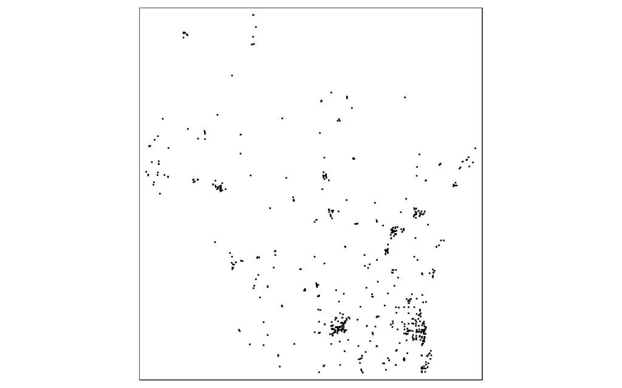

```r
tm_shape(ev) +
    tm_dots()
```

5. [Zion Elevation](https://github.com/krisrs1128/stat436_s24/raw/main/data/landsat.tif)

Raster. This is because the object is class `RasterLayer`. We have elevation at 30 meter resolution across the park.

```r
zion <- brick("https://github.com/krisrs1128/stat436_s24/raw/main/data/landsat.tif") |>
    subset(4)
zion
```

```
## class      : RasterLayer
## band       : 4  (of  4  bands)
## dimensions : 1428, 1128, 1610784  (nrow, ncol, ncell)
## resolution : 30, 30  (x, y)
## extent     : 301905, 335745, 4111245, 4154085  (xmin, xmax, ymin, ymax)
## crs        : +proj=utm +zone=12 +datum=WGS84 +units=m +no_defs
## source     : landsat.tif
## names      : landsat_4
## values     : 5252, 31961  (min, max)
```

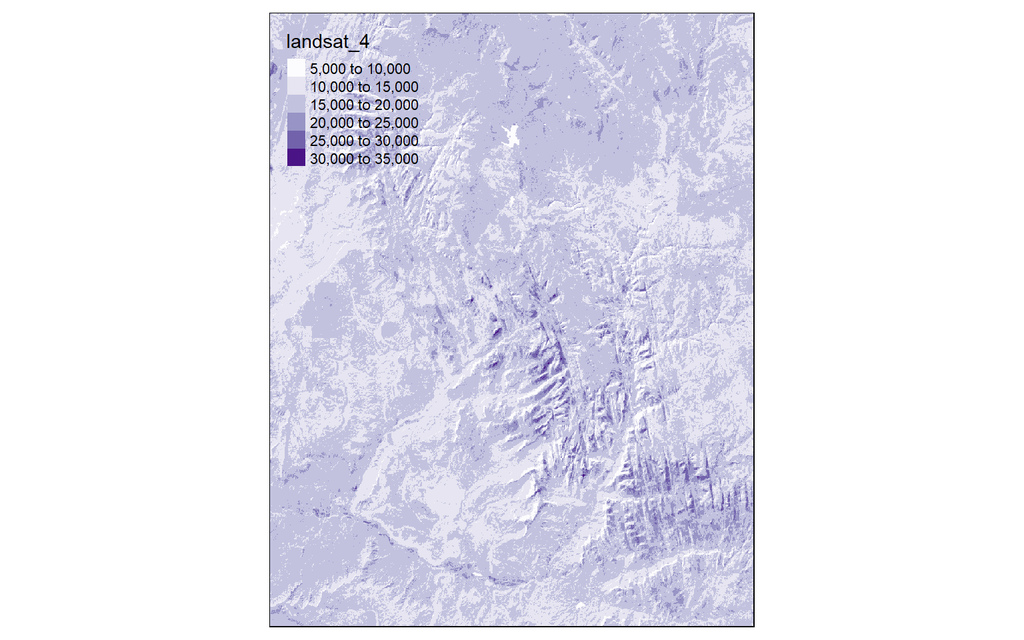

```r
tm_shape(zion) +
    tm_raster(palette = c('#fcfbfd','#efedf5','#dadaeb','#bcbddc','#9e9ac8','#807dba','#6a51a3','#4a1486'))
```

# CalFresh Comparison

```r
library(tsibble)
library(feasts)
unemployment <- read_sf("https://raw.githubusercontent.com/krisrs1128/stat436_s25/refs/heads/main/data/unemployment.geojson") |>
  mutate(date = yearmonth(date))
focus <- c("Colusa", "Monterey", "San Francisco", "Imperial", "Los Angeles", "San Joaquin")
head(unemployment, 3)
```

```
## Simple feature collection with 3 features and 4 fields
## Geometry type: MULTIPOLYGON
## Dimension:     XY
## Bounding box:  xmin: -122.3316 ymin: 37.45444 xmax: -121.4693 ymax: 37.90502
## Geodetic CRS:  WGS 84
## # A tibble: 3 × 5
##   county      date  year unemployment                                   geometry
##   <chr>      <mth> <dbl>        <dbl>                         <MULTIPOLYGON [°]>
## 1 Alameda 2014 Jan  2014          6.5 (((-122.3129 37.89733, -122.2885 37.89793…
## 2 Alameda 2014 Feb  2014          6.4 (((-122.3129 37.89733, -122.2885 37.89793…
## 3 Alameda 2014 Mar  2014          6.4 (((-122.3129 37.89733, -122.2885 37.89793…
```

3. Provide code to answer: For each county and year, what was the maximum unemployment rate across all months?

```r
unemployment |>
  group_by(county, year) |>
  summarise(max_unemployed = max(unemployment, na.rm = TRUE))
```

```
## Simple feature collection with 385 features and 3 fields
## Geometry type: GEOMETRY
## Dimension:     XY
## Bounding box:  xmin: -124.4087 ymin: 32.53429 xmax: -114.1312 ymax: 42.00952
## Geodetic CRS:  WGS 84
## # A tibble: 385 × 4
## # Groups:   county [55]
##    county   year max_unemployed                                         geometry
##    <chr>   <dbl>          <dbl>                                   <GEOMETRY [°]>
##  1 Alameda  2014            6.5 MULTIPOLYGON (((-122.317 37.88919, -122.3028 37…
##  2 Alameda  2015            5.3 MULTIPOLYGON (((-122.317 37.88919, -122.3028 37…
##  3 Alameda  2016            4.7 MULTIPOLYGON (((-122.317 37.88919, -122.3028 37…
##  4 Alameda  2017            4.3 MULTIPOLYGON (((-122.317 37.88919, -122.3028 37…
##  5 Alameda  2018            3.3 MULTIPOLYGON (((-122.317 37.88919, -122.3028 37…
##  6 Alameda  2019            3.3 MULTIPOLYGON (((-122.317 37.88919, -122.3028 37…
##  7 Alameda  2020           14.1 MULTIPOLYGON (((-122.317 37.88919, -122.3028 37…
##  8 Alpine   2014           10.2 POLYGON ((-120.0724 38.70128, -120.0725 38.6249…
##  9 Alpine   2015            8.8 POLYGON ((-120.0724 38.70128, -120.0725 38.6249…
## 10 Alpine   2016            8   POLYGON ((-120.0724 38.70128, -120.0725 38.6249…
## # ℹ 375 more rows
```

4. Provide code to implement one of the figures above. You may assume the result from part (c) and do not need to match color or text themes.

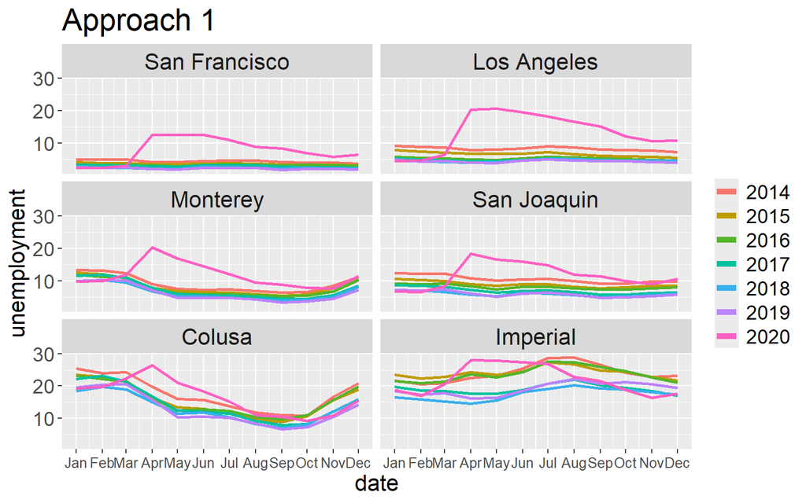

```r
library(scico)
library(tmap)

p1 <- unemployment |>
  as_tsibble(county, date) |>
  filter(county %in% focus) |>
  gg_season(unemployment, linewidth = 1) +
  guides(color = guide_legend(override.aes = list(linewidth = 2))) +
  facet_wrap(~ reorder(county, unemployment), ncol = 2) +
  labs(title = "Approach 1") +
  theme(
    title = element_text(size = 18),
    axis.title = element_text(size = 16),
    axis.text.y = element_text(size = 14),
    axis.text.x = element_text(size = 10),
    strip.text = element_text(size = 16),
    legend.text = element_text(size = 14),
    legend.position = "right"
  )

p2 <- ggplot(unemployment) +
  geom_tile(
    aes(
      as_date(date),
      reorder(county, unemployment, na.rm = TRUE),
      fill = sqrt(unemployment),
      col = sqrt(unemployment)
    ),
    linewidth = 1
  ) +
  scale_x_date(expand = c(0, 0)) +
  scale_fill_scico(palette = "roma") +
  scale_color_scico(palette = "roma") +
  labs(x = "Date", y = "County", fill = "sqrt(Unemployment %)", color = "sqrt(Unemployment %)", title = "Approach 2") +
  theme(
    title = element_text(size = 18),
    axis.title = element_text(size = 18),
    axis.text.y = element_text(size = 8),
    axis.text.x = element_text(size = 16),
    legend.text = element_text(size = 16),
    legend.title = element_text(size = 18)
  )

p3 <- unemployment |>
  group_by(county, year) |>
  summarise(max_unemployed = max(unemployment, na.rm = TRUE)) |>
  tm_shape() +
  tm_polygons(col = "max_unemployed", title = "Max. Unemployed") +
  tm_facets("year", ncol = 4) +
  tm_layout(
    main.title = "Approach 3",
    title.size = 14
  )

p1
```

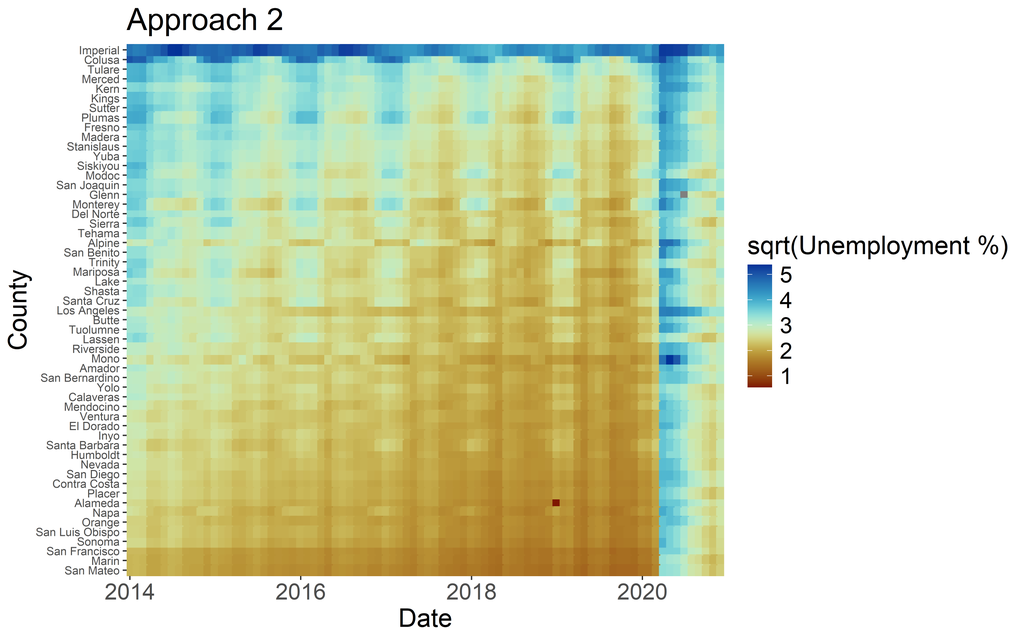

```r
p2
```

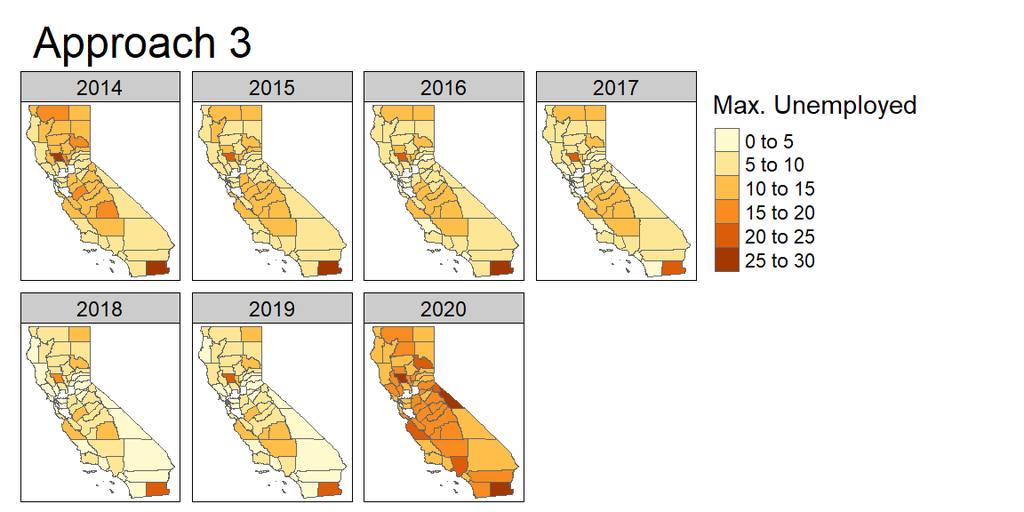

```r
p3
```

# HIV Network

1. Provide code to generate a node-link visualization similar to that in Figure 14. Make at least one style customization that improves the visualization. Justify your choice.

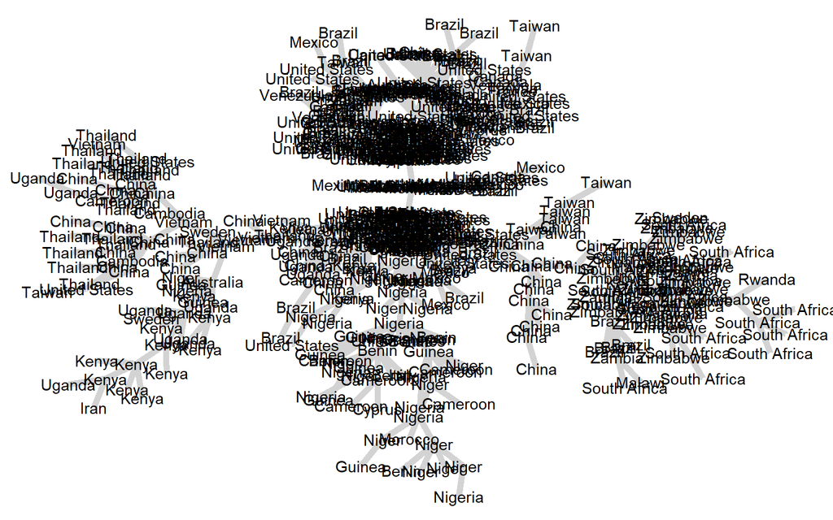

```r
    library(tidygraph)
    nodes <- read_csv("https://github.com/krisrs1128/stat436_s25/raw/refs/heads/main/data/hiv_nodes.csv")
    edges <- read_csv("https://github.com/krisrs1128/stat436_s25/raw/refs/heads/main/data/hiv_edges.csv")
    G <- tbl_graph(nodes, edges)

    library(ggraph)
    ggraph(G) +
      geom_edge_link(colour = "#d3d3d3", alpha = 0.9, width = 2) +
      geom_node_text(aes(label = name)) +
      theme_void()
```

```r
tibble(
  node = 1:5,
  `1` = c(0, 1, 1, 0, 1),
  `2` = c(1, 0, 0, 1, 0),
  `3` = c(1, 0, 0, 0, 0),
  `4` = c(0, 1, 0, 0, 0),
  `5` = c(1, 0, 0, 0, 0)
) %>%
  column_to_rownames(var = "node")
```

```
##   1 2 3 4 5
## 1 0 1 1 0 1
## 2 1 0 0 1 0
## 3 1 0 0 0 0
## 4 0 1 0 0 0
## 5 1 0 0 0 0
```

The three cluster structure of the node-link visualization would result in an adjacency matrix with three distinct, dense blocks of 1’s, with a smattering of 1’s not in those blocks representing the small number of connections across clusters.

# Beijing Air Pollution

This problem studies daily air pollution and weather patterns in Beijing from 2010 to 2014. Each row in this dataset gives measurements for three variables, `pollution`, `temp`, and `wndspd` over time for a single day, indexed by `date`. For example the `temp_13` column gives the temperature at 1pm. Note that both `pollution` and `wndspd` have been $\log\left(1 + x\right)$ transformed.

```
a. Cluster all the days using a hierarchical clustering. Be sure to scale
the columns in advance, so that no single variable has undue influence on
the result. Cut the tree so that we are left with 10 clusters, and provide a
ribbon plot to visualize several quantiles associated with each cluster's
typical pollution, temperature, and windspeed trajectories. visualization to
understand the centroids of each cluster. Briefly interpret the main
patterns you observe.
```

```r
pollution <- read_csv("https://raw.githubusercontent.com/krisrs1128/stat436_s25/refs/heads/main/data/pollution_wide.csv")

fit <- pollution %>%
  select(-date) %>%
  scale() %>%
  dist() %>%
  hclust()
```

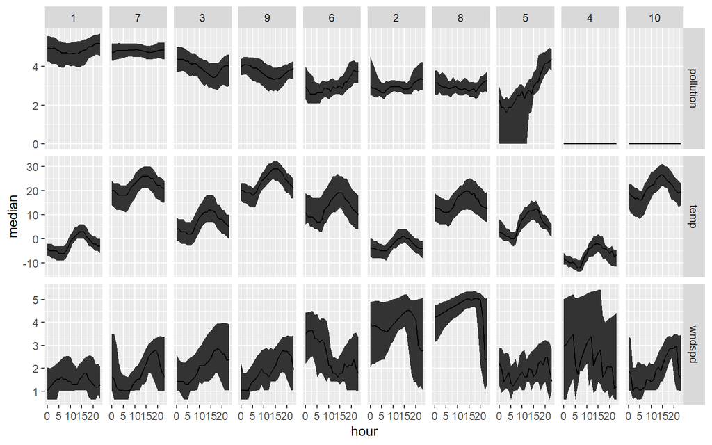

```r
ribbon_data <- pollution %>%
  mutate(cluster = cutree(fit, k = 10)) %>%
  pivot_longer(contains("_")) %>%
  separate(name, c("variable", "hour"), convert = TRUE) %>%
  group_by(cluster, variable, hour) %>%
  summarise(
    q1 = quantile(value, 0.25),
    median = median(value),
    q3 = quantile(value, 0.75)
  )

cluster_order <- ribbon_data %>%
  filter(variable == "pollution") %>%
  group_by(cluster) %>%
  summarise(m = mean(median)) %>%
  arrange(-m) %>%
  pull(cluster)

ribbon_data <- ribbon_data %>%
  mutate(cluster = factor(cluster, levels = cluster_order))

ggplot(ribbon_data) +
  geom_ribbon(aes(hour, ymin = q1, ymax = q3)) +
  geom_line(aes(hour, median)) +
  facet_grid(variable ~ cluster, scale = "free_y")
```